# Training and tuning svm

Jose M Sallan

04/05/2020

```r
library(tidyverse)
library(caret)
library(e1071)
library(BAdatasets)
```

# 1 A classification problem with `WineQuality`

Let’s define a classification problem with the `WineQuality` dataset, accesible through the `BAdatasets` package. We’ll pick the dataset of red wines, and define a `good` variable defining good wines with `quality` equal or higher than 6 and bad otherwise. We’ll pick 80% of the dataset as train set.

```r
red <- WineQuality$red

red <- red %>% mutate(good = as.factor(ifelse(quality >= 6, 1, 0)))
red <- red %>% select(-quality)
levels(red$good) <- c("bad", "good")

set.seed(2020)
inTrain <- createDataPartition(red$good, p=0.8, list = FALSE)
red_train <- red %>% slice(inTrain)
red_test <- red %>% slice(-inTrain)

red_train <- data.frame(red_train)
red_test <- data.frame(red_test)
```

For obtaining accuracy, we’ll use cross-validation with 5 folders.

```r
 control <- trainControl(method = "cv", number = 5)
```

# 2 Classification benchmarks

We’ll use two classification algorithms as benchmarks for the `svm` implementation.

```r
set.seed(2020)
c50 <- train(red_train %>% select(-good), red_train$good,
                 method = "C5.0",
                 trControl = control, tuneGrid = expand.grid(model=c("rules", "tree"), winnow=c(TRUE, FALSE), trials=c(10, 20)))
set.seed(2020)
rf <- train(good ~ ., red_train,
                method = "rf",
                trControl = control, tuneLength = 7, ntree=100)
```

Let’s check accuracy values:

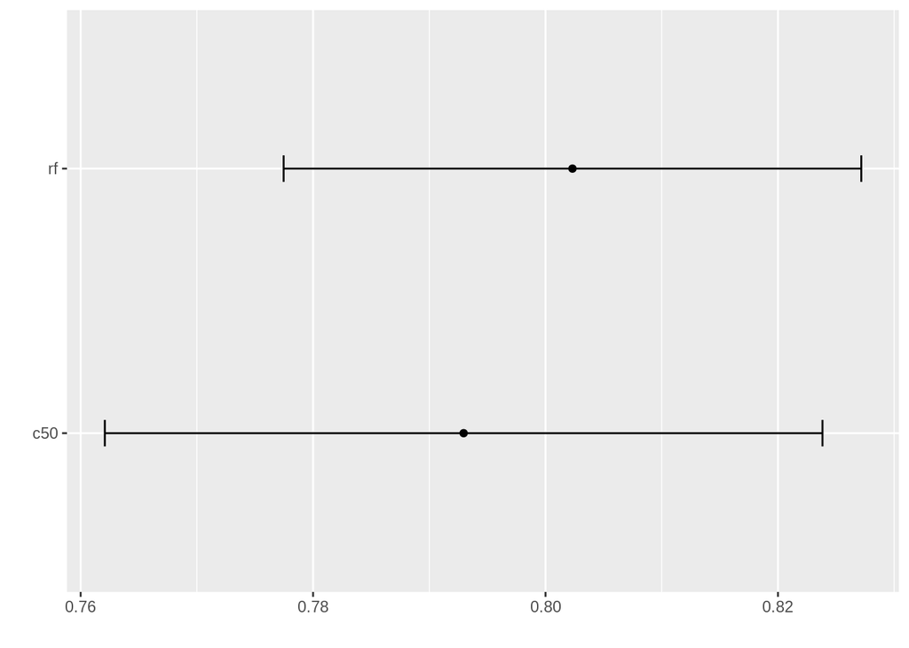

```r
models01 <- list(c50=c50, rf=rf)
resamps01 <- resamples(models01)
ggplot(resamps01, models=resamps01$models, metric="Accuracy")
```

# 3 Support vector machines with `e1071`

Let’s run some support vector machine models with the `svm` function of the `e1071` package.

```r
svm_linear <- svm(good ~ ., red_train, kernel="linear")
svm_poly <- svm(good ~ ., red_train, kernel="poly")
svm_radial <- svm(good ~ ., red_train, kernel="radial")
```

Let’s examine the values of accuracy for the obtained models.

```r
postResample(svm_linear$fitted, red_train$good)
```

```
##  Accuracy     Kappa
## 0.7445312 0.4893368
```

```r
postResample(svm_poly$fitted, red_train$good)
```

```
##  Accuracy     Kappa
## 0.7984375 0.5958330
```

```r
postResample(svm_radial$fitted, red_train$good)
```

```
##  Accuracy     Kappa
## 0.8062500 0.6109956
```

The values of accuracy are on a similar range than the benchmark models. Let’s see if we can improve performance using `caret` for model tuning.

# 4 Tuning svm models with caret

Many of the methods available for SVM with `caret` come from the `kernlab` package. Let’s start tuning a linear SVM model with several values of the cost `C` parameter.

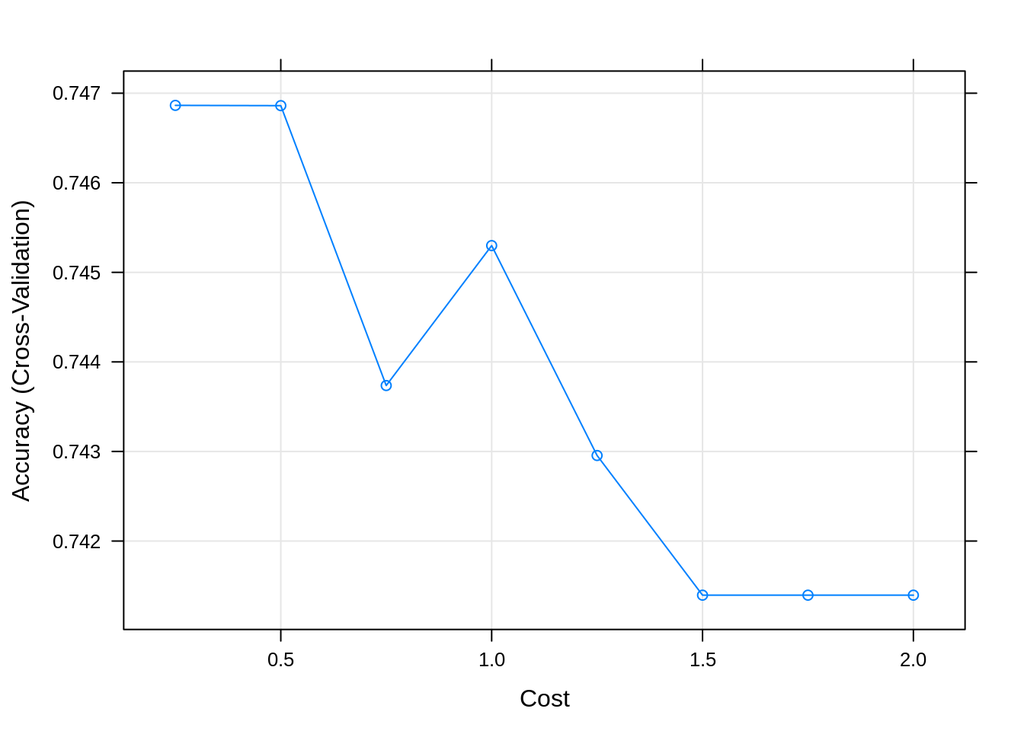

```r
set.seed(2020)
svm_linear_caret <- train(good ~ ., red_train, method="svmLinear", trControl = control, tuneGrid=expand.grid(C=seq(0.25, 2, 0.25)))
plot(svm_linear_caret)
```

I have set a seed for random numbers as the best choice can experiment significant variations, altough the range of improvement of accuracy is small. The value of accuracy is similar to the obtained for the linear kernel with the `svm` function.

Let’s train a polynomial model. In this model I have fixed the `scale` parameter equal to the inverse of number of features, as different values lead to problematic results.

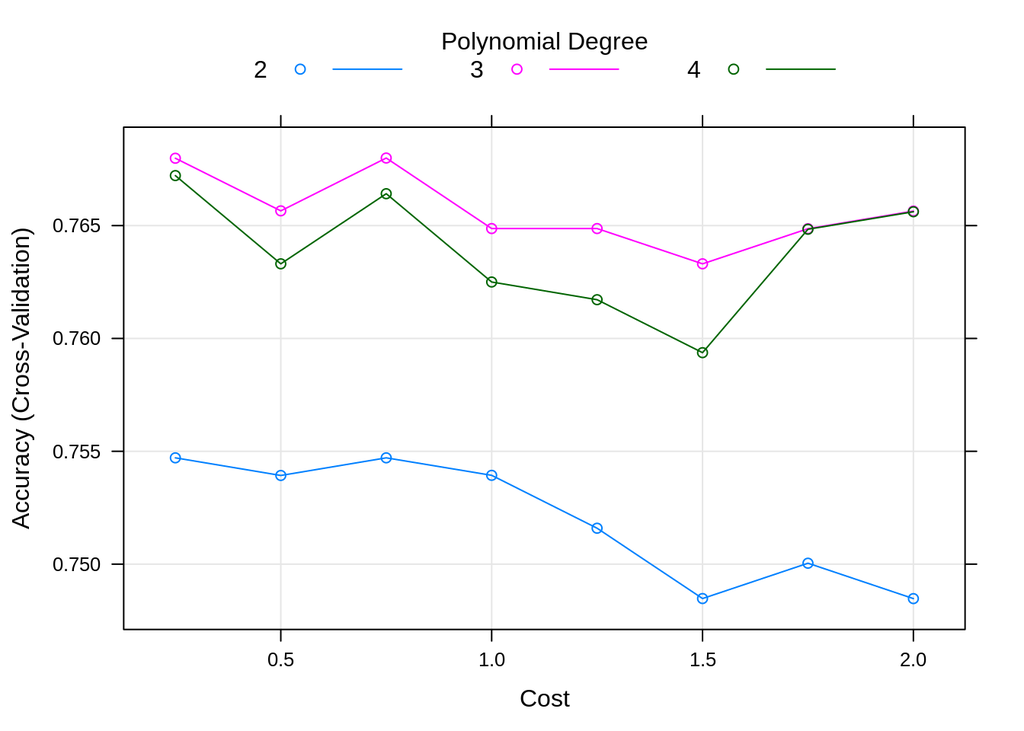

```r
set.seed(2020)
svm_poly_caret <- train(good ~ ., red_train, method="svmPoly", trControl = control, tuneGrid=expand.grid(C=seq(0.25, 2, 0.25), degree=2:4, scale=1/11))
plot(svm_poly_caret)
```

And let’s train finally a radial model:

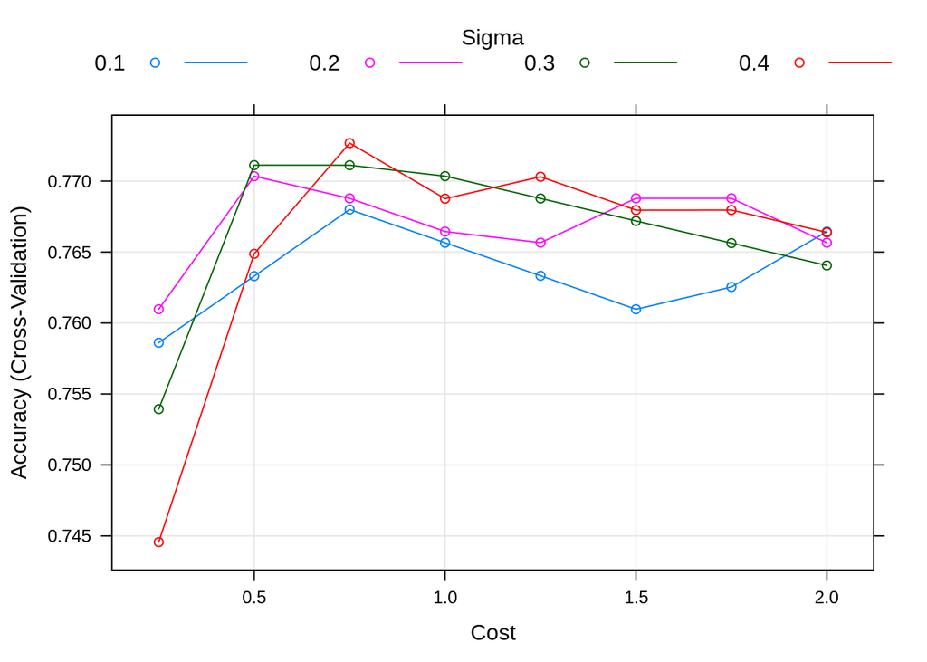

```r
set.seed(2020)
svm_radial_caret <- train(good ~ ., red_train, method="svmRadial", trControl = control, tuneGrid=expand.grid(C=seq(0.25, 2, 0.25), sigma=seq(0.1, 0.4, 0.1)))
plot(svm_radial_caret)
```

Among the SVM models, the radial is the one that seems to have best results.

# 5 Comparing performance on the test set

```r
test_rf <- predict(rf, red_test)
confusionMatrix(test_rf, red_test$good)
```

```
## Confusion Matrix and Statistics
##
##           Reference
## Prediction bad good
##       bad  118   32
##       good  30  139
##
##                Accuracy : 0.8056
##                  95% CI : (0.7579, 0.8476)
##     No Information Rate : 0.5361
##     P-Value [Acc > NIR] : <2e-16
##
##                   Kappa : 0.6096
##
##  Mcnemar's Test P-Value : 0.8989
##
##             Sensitivity : 0.7973
##             Specificity : 0.8129
##          Pos Pred Value : 0.7867
##          Neg Pred Value : 0.8225
##              Prevalence : 0.4639
##          Detection Rate : 0.3699
##    Detection Prevalence : 0.4702
##       Balanced Accuracy : 0.8051
##
##        'Positive' Class : bad
##
```

```r
test_svm_radial <- predict(svm_radial_caret, red_test)
confusionMatrix(test_svm_radial, red_test$good)
```

```
## Confusion Matrix and Statistics
##
##           Reference
## Prediction bad good
##       bad  104   40
##       good  44  131
##
##                Accuracy : 0.7367
##                  95% CI : (0.6847, 0.7842)
##     No Information Rate : 0.5361
##     P-Value [Acc > NIR] : 1.403e-13
##
##                   Kappa : 0.4696
##
##  Mcnemar's Test P-Value : 0.7434
##
##             Sensitivity : 0.7027
##             Specificity : 0.7661
##          Pos Pred Value : 0.7222
##          Neg Pred Value : 0.7486
##              Prevalence : 0.4639
##          Detection Rate : 0.3260
##    Detection Prevalence : 0.4514
##       Balanced Accuracy : 0.7344
##
##        'Positive' Class : bad
##
```

The random forests implementation is still the better classifyer for this task, but the SVM implementation has also a good performance on the test set.